# Data Challenge competition - Football prediction

Attila Gulyás / Team Bella Vita

Note: - Data was provided by the organizer of the competition. It is found to be clean, no missing values, no duplicates. - There are 23 divisions and 10 seasons in the data.

BASIC SETUP

```r
# empty memory
rm(list=ls())

# KOMMENT: install library if not exist -> megoldani majd

# Load libraries
library("tidyverse") # imap function for roc curve
library("data.table") # to use data in an efficient way
library("readxl") # to read xlsx data
library("caret") # to split data into train and holdput sets
library("dplyr") # to append commands easier
library("ROCR") # to evaluate model performance
library("h2o") # for autoML, java is kell hozzá
library("xgboost") # for extreme gradient boosting model
library("e1071") # for Naive Bayes
library("ranger") # for RF model
library("kernlab") # for SVM
library("mltools") # to calculate AUC manually
library("glmnet") # for GLMNET model
# library(ggplot2)
# library(ggthemes)
# library(grid)
# library(lattice)
# library(glmnet)
# library("skimr")
# library(gridExtra)

# Set the working directory
dir <-  "/Users/attilagulyas/Documents/GitHub/DataChallenge2023/"

#location folders
data_in <- paste0(dir,"01_raw/")
# func <- paste0(dir, "work/") - nem használt
output <- paste0(dir, "04_output/")
```

LOAD DATA

```r
data <- as.data.table(read_excel(paste0(data_in, "competition_table.xlsx")))


# BASIC STISTICS
message(paste0("Döntetlen aránya: ", round(sum(data$draw_flag) / nrow(data), digits = 2)))
```

```
Döntetlen aránya: 0.26
```

```r
message(paste0("Hazai győzelem aránya: ", round(sum(data$home_win_flag) / nrow(data), digits = 2)))
```

```
Hazai győzelem aránya: 0.44
```

```r
message(paste0("Vendég győzelem aránya: ", round(sum(data$away_win_flag) / nrow(data), digits = 2)))
```

```
Vendég győzelem aránya: 0.3
```

LABEL ENGINEERING

```r
data <- data %>%
  mutate(home_win_flag = factor(ifelse(home_win_flag == 0, "no", "yes"), levels = c("no", "yes")))

data <- data %>%
  mutate(away_win_flag = factor(ifelse(away_win_flag == 0, "no", "yes"), levels = c("no", "yes")))

data <- data %>%
  mutate(draw_flag = factor(ifelse(draw_flag == 0, "no", "yes"), levels = c("no", "yes")))
```

FEATURE ENGINEERING

```r
# data structure
str(data)
```

```
Classes ‘data.table’ and 'data.frame':  64166 obs. of  167 variables:
 $ match_id                                    : num  0 1 2 3 4 5 6 7 8 9 ...
 $ season                                      : chr  "2008-2009" "2008-2009" "2008-2009" "2008-2009" ...
 $ div                                         : chr  "div0" "div0" "div0" "div0" ...
 $ odds_home_team_win                          : num  1.73 1.25 1.57 1.17 1.17 1.62 1.44 1.25 1.33 1.14 ...
 $ odds_draw                                   : num  3.5 5.5 3.8 7 7 3.8 4 5.5 5 7.5 ...
 $ odds_away_team_win                          : num  5 12 5.75 15 15 5.5 8 12 9 17 ...
 $ home_team_match_nr                          : num  5 7 9 11 14 16 19 21 23 25 ...
 $ home_team_goal_roll1_sum                    : num  3 0 1 2 2 2 0 1 0 3 ...
 $ home_team_goal_roll2_sum                    : num  7 2 4 6 4 6 2 4 1 8 ...
 $ home_team_goal_roll3_sum                    : num  8 5 4 7 7 8 4 4 2 8 ...
 $ home_team_goal_roll4_sum                    : num  10 9 6 10 9 10 6 6 5 9 ...
 $ home_team_opponents_goal_roll1_sum          : num  0 1 0 1 2 0 1 2 0 0 ...
 $ home_team_opponents_goal_roll2_sum          : num  1 6 3 3 3 1 3 3 2 1 ...
 $ home_team_opponents_goal_roll3_sum          : num  2 6 4 3 4 3 4 4 4 1 ...
```

[output cut: 87 more lines]

```r
# itt hozzunk majd létre az új változókat
```

| MODEL FOR PREDICTING HOME WIN |
| --- |

Create training set and holdout set samples Megj: 80%os trainingsettel is kipróbálni!

```r
set.seed(1990)

# smaller than usual training set so that models run faster
train_indices <- createDataPartition(data$home_win_flag, p = 0.7, list = FALSE)
data_train <- data[train_indices, ]

data_holdout <- data[-train_indices, ]

dim(data_train)
```

```
[1] 44917   167
```

```r
dim(data_holdout)
```

```
[1] 19249   167
```

Set evaluation rules Megj: 10-fold CV, repeated CV is megoldás lehet, kipróbálni

```r
train_control <- trainControl(
  method = "cv",
  n = 5,
  classProbs = TRUE,
  summaryFunction = twoClassSummary  # necessary!
)

# MEGJ: repeated CV is egy megoldás

# Define the control parameters for the train function
# ctrl <- trainControl(method = "repeatedcv", number = 10, repeats = 3,
#                      classProbs = TRUE, summaryFunction = twoClassSummary)
```

Define variables

```r
# Basic numeric variables
basic_numeric_vars <- c(
  "odds_home_team_win",
  "odds_away_team_win",
  "odds_draw"
)

basic_numeric_vars_set2 <- c("odds_away_team_win",
                             "odds_home_team_win",
                             "odds_draw",

                             "odds_home_team_defeat_roll4_mean",
                             "odds_away_team_defeat_roll4_mean",
                             "odds_home_team_win_roll4_mean",
                             "odds_away_team_win_roll4_mean",

                             "odds_home_team_defeat_roll3_mean",
                             "odds_away_team_defeat_roll3_mean",
                             "odds_home_team_win_roll3_mean",
                             "odds_away_team_win_roll3_mean",

                             "odds_home_team_defeat_roll2_mean",
                             "odds_away_team_defeat_roll2_mean",
                             "odds_home_team_win_roll2_mean",
                             "odds_away_team_win_roll2_mean",

                             "odds_home_team_defeat_roll1_mean",
                             "odds_away_team_defeat_roll1_mean",
                             "odds_home_team_win_roll1_mean",
                             "odds_away_team_win_roll1_mean",

                             "home_team_expected_point_mean",
                             "away_team_expected_point_mean",
                             "home_team_expected_point_roll4_sum",
                             "away_team_expected_point_roll4_sum"
                             )

# Log variables

# Higher order variables

# Factorized variables

# Dummy variables
```

Define predictor sets

```r
predictors_1 <- c(basic_numeric_vars)
predictors_2 <- colnames(data[,-c("home_win_flag", "draw_flag", "away_win_flag", "match_id")])
predictors_3 <- c(basic_numeric_vars_set2)
```

| MODELLEK: |
| --- |

## AutoML model: baseline model

```r
h2o.init()
```

```
H2O is not running yet, starting it now...

Note:  In case of errors look at the following log files:
    /var/folders/v_/l5zp744d5z350b__prjsk4r40000gn/T//RtmpDRmQDF/filef9056523f99/h2o_attilagulyas_started_from_r.out
    /var/folders/v_/l5zp744d5z350b__prjsk4r40000gn/T//RtmpDRmQDF/filef9031cd8215/h2o_attilagulyas_started_from_r.err
```

```
java version "1.8.0_361"
Java(TM) SE Runtime Environment (build 1.8.0_361-b09)
Java HotSpot(TM) 64-Bit Server VM (build 25.361-b09, mixed mode)
```

[output not shown]

```r
data_train_h2o <- as.h2o(data_train[,-c("away_win_flag", "draw_flag")])
# Define the target variable
target <- "home_win_flag"

# Split data into training and validation sets
splits <- h2o.splitFrame(data_train_h2o, ratios = 0.8, seed = 1234)
train <- splits[[1]]
valid <- splits[[2]]

set.seed(857)
# Run AutoML for 20 base models
aml = h2o.automl(x = predictors_2, y = target,
                 training_frame = train,
                 validation_frame = valid,
                 max_models = 20,
                 seed = 1,
                 max_runtime_secs = 20
)
```

```
22:31:43.123: _train param, Dropping bad and constant columns: [div, season]
22:31:59.427: _train param, Dropping bad and constant columns: [div, season]
```

```r
# AutoML Leaderboard
lb = aml@leaderboard
lb
```

|  | model_id | auc | logloss | aucpr | mean_per_class_error | rmse | mse |
| --- | --- | --- | --- | --- | --- | --- | --- |
| 1 | GLM_1_AutoML_1_20230225_223142 | 0.6782683 | 0.6329331 | 0.622355 | 0.3993085 | 0.4706575 | 0.2215185 |
| 2 | XGBoost_1_AutoML_1_20230225_223142 | 0.6297096 | 0.7099867 | 0.571618 | 0.4585730 | 0.4996881 | 0.2496882 |

```
[2 rows x 7 columns]
```

```r
# close h2o connection
h2o.shutdown(prompt = F)
```

## Logistic regression

megj: a változószelekción még dolgozni kell: 1) domain knowledge

```r
#  train the model
set.seed(857)

glm_model <- train(home_win_flag ~ .,
                   data = data_train[ ,colnames(data_train) %in% c("home_win_flag", predictors_1), with=FALSE],
                   method = "glm",
                   trControl = train_control)
```

```r
# model summary
summary(glm_model)
```

```
Call:
NULL

Deviance Residuals:
    Min       1Q   Median       3Q      Max
-3.2034  -1.0360  -0.7227   1.1915   3.5325

Coefficients:
                   Estimate Std. Error z value Pr(>|z|)
(Intercept)        -0.31383    0.07474  -4.199 2.68e-05 ***
odds_home_team_win -0.38323    0.01855 -20.662  < 2e-16 ***
odds_draw           0.15298    0.03549   4.310 1.63e-05 ***
odds_away_team_win  0.11365    0.01305   8.706  < 2e-16 ***
---
Signif. codes:  0 ‘***’ 0.001 ‘**’ 0.01 ‘*’ 0.05 ‘.’ 0.1 ‘ ’ 1

(Dispersion parameter for binomial family taken to be 1)

    Null deviance: 61614  on 44916  degrees of freedom
Residual deviance: 56775  on 44913  degrees of freedom
AIC: 56783

Number of Fisher Scoring iterations: 4
```

```r
# AUC on validation set
auc_cv <- glm_model[["results"]][["ROC"]]
message(paste0("AUC from CV: ", round(auc_cv, digits = 4)))
```

```
AUC from CV: 0.6814
```

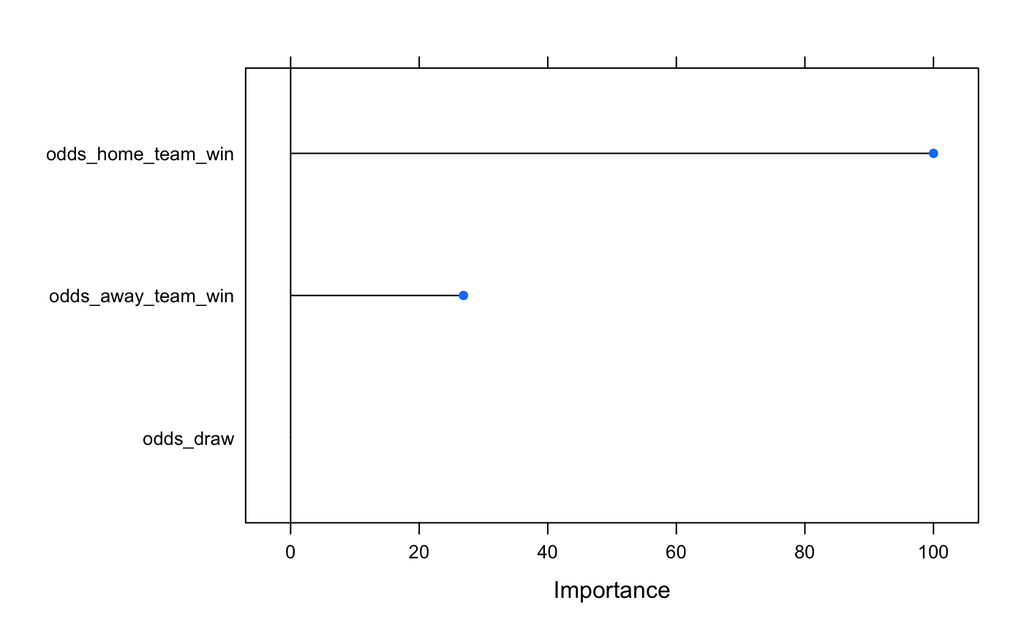

```r
# variable importance
varimp <- varImp(glm_model)
plot(varImp(glm_model))
```

## GLMNET model (Reguralized logistic regression)

```r
#  train the model
set.seed(857)

tune_grid_glmnet <- expand.grid(
               alpha = 0.5, #ridge: 0, lasso: 1, elastic net: [0,1]
               lambda = c(0.1)
)

glmnet_model <- train(home_win_flag ~ .,
                   data = data_train[ ,colnames(data_train) %in% c("home_win_flag", predictors_2), with=FALSE],
                   method = "glmnet",
                   trControl = train_control,
                   tuneGrid = tune_grid_glmnet)
```

```r
# model summary
summary(glmnet_model)
```

```
            Length Class      Mode
a0             84  -none-     numeric
beta        16464  dgCMatrix  S4
df             84  -none-     numeric
dim             2  -none-     numeric
lambda         84  -none-     numeric
dev.ratio      84  -none-     numeric
nulldev         1  -none-     numeric
npasses         1  -none-     numeric
jerr            1  -none-     numeric
offset          1  -none-     logical
classnames      2  -none-     character
call            5  -none-     call
nobs            1  -none-     numeric
lambdaOpt       1  -none-     numeric
xNames        196  -none-     character
problemType     1  -none-     character
tuneValue       2  data.frame list
obsLevels       2  -none-     character
param           0  -none-     list
```

```r
# AUC on validation set
auc_cv <- glmnet_model[["results"]][["ROC"]]
message(paste0("AUC from CV: ", round(auc_cv, digits = 4)))
```

```
AUC from CV: 0.6807
```

```r
varimp
```

[output not shown]

[output not shown]

[output cut: 10 more lines]

## Extreme Gradient Boosting

```r
#  train the model
set.seed(19900829)
tune_grid_xgb <- expand.grid(
  nrounds = c(100),  # this is n_estimators in the python code above
  max_depth = c(10),
  colsample_bytree = seq(0.5, 0.9, length.out = 5),
  ## The values below are default values in the sklearn-api.
  eta = 0.1,
  gamma=0,
  min_child_weight = 1,
  subsample = 1
)


xgb_model <- train(
  home_win_flag ~ .,
  data = data_train[ ,colnames(data_train) %in% c("home_win_flag", predictors_2), with=FALSE],
  tuneLength = 1,
  method = 'xgbTree',
  na.action = na.omit,
  # importance = 'permutation',
  # mtry: cannot be more than the number of predictors
  tuneGrid = tune_grid_xgb,
  trControl = train_control)
```

```r
# model summary
summary(xgb)
```

[output not shown]

```r
# AUC on validation set
auc_cv <- xgb_model[["results"]][["ROC"]]
message(paste0("AUC from CV: ", round(auc_cv, digits = 4)))
```

[output not shown]

```r
varimp
```

[output not shown]

[output not shown]

[output cut: 10 more lines]

## “Simple” Gradient Boosting Machine

```r
#  train the model
set.seed(19900829)
tune_grid_gbm <- expand.grid(n.trees = 100,
                        interaction.depth = c(5),
                        shrinkage = c(0.005),
                        n.minobsinnode = c(5))

gbm_model <- train(home_win_flag ~ .,
                   data = data_train[ ,colnames(data_train) %in% c("home_win_flag", predictors_2), with=FALSE],
                   method = "gbm",
                   trControl = train_control,
                   tuneGrid = tune_grid_gbm,
                   bag.fraction = 0.8,
                   verbose = FALSE # gbm by default prints too much output
)
```

```r
# model summary
# summary(gbm_model)
```

```r
# AUC on validation set
auc_cv <- gbm_model[["results"]][["ROC"]]
message(paste0("AUC from CV: ", round(auc_cv, digits = 4)))
```

```
AUC from CV: 0.6811
```

```r
varimp <- varImp(gbm_model)
```

```
Error in relative.influence(object, n.trees = numTrees) :
  could not find function "relative.influence"
```

## Naive Bayes

```r
#  train the model
set.seed(19900829)

nb_model <- train(home_win_flag ~ .,
                  data = data_train[ ,colnames(data_train) %in% c("home_win_flag", predictors_2), with=FALSE],
                  method = "naive_bayes",
                  trControl = train_control, verbose = FALSE)
```

[output not shown]

[output cut: 2286 more lines]

[output not shown]

```r
# model summary
summary(nb_model)
```

```
================================================== Naive Bayes ===================================================

- Call: naive_bayes.default(x = x, y = y, laplace = param$laplace, usekernel = TRUE,      adjust = param$adjust, verbose = FALSE)
- Laplace: 0
- Classes: 2
- Samples: 44917
- Features: 195
- Conditional distributions:
    - KDE: 195
- Prior probabilities:
    - no: 0.5603
    - yes: 0.4397

------------------------------------------------------------------------------------------------------------------
```

```r
# AUC on validation set
auc_cv <- nb_model[["results"]][["ROC"]]
message(paste0("AUC from CV: ", round(auc_cv, digits = 4)))
```

```
AUC from CV: 0.6592AUC from CV: 0.6629
```

```r
varimp <- varImp(nb_model)
```

```
Error in auc3_(actual, predicted, ranks) :
  Not compatible with requested type: [type=character; target=double].
```

## Random Forest

```r
#  train the model
set.seed(19900829)
tune_grid_rf <- expand.grid(
  .mtry = 3,
  .splitrule = "gini",
  .min.node.size = c(5) # implicitly sets the depth of your trees
)


rf_model <- train(
  home_win_flag ~ .,
  data = data_train[ ,colnames(data_train) %in% c("home_win_flag", predictors_2), with=FALSE],
  tuneLength = 1,
  method = 'ranger',
  na.action = na.omit,
  importance = 'permutation',
  # mtry: cannot be more than the number of predictors
  tuneGrid = tune_grid_rf,
  trControl = train_control)
```

```r
# model summary
summary(rf_model)
```

```
                          Length Class         Mode
predictions               89834  -none-        numeric
num.trees                     1  -none-        numeric
num.independent.variables     1  -none-        numeric
mtry                          1  -none-        numeric
min.node.size                 1  -none-        numeric
variable.importance         195  -none-        numeric
prediction.error              1  -none-        numeric
forest                       10  ranger.forest list
splitrule                     1  -none-        character
treetype                      1  -none-        character
call                          9  -none-        call
importance.mode               1  -none-        character
num.samples                   1  -none-        numeric
replace                       1  -none-        logical
xNames                      195  -none-        character
problemType                   1  -none-        character
tuneValue                     3  data.frame    list
obsLevels                     2  -none-        character
param                         1  -none-        list
```

```r
# AUC on validation set
auc_cv <- rf_model[["results"]][["ROC"]]
message(paste0("AUC from CV: ", round(auc_cv, digits = 4)))
```

```
AUC from CV: 0.6716
```

[figure not shown]

```r
varimp <- varImp(rf_model)
plot(varImp(rf_model))
```

```r
varimp
```

```
ranger variable importance

  only 20 most important variables shown (out of 195)
```

|  | Overall |
| --- | --- |
| odds_away_team_win | 100.00000 |
| odds_home_team_win | 93.16422 |
| odds_draw | 38.82186 |
| odds_home_team_defeat_roll4_mean | 38.40511 |
| odds_home_team_defeat_roll3_mean | 34.68328 |
| odds_away_team_defeat_roll4_mean | 33.28216 |
| away_team_expected_point_mean | 31.41100 |
| odds_home_team_win_roll4_mean | 30.65799 |
| odds_away_team_defeat_roll3_mean | 30.31268 |
| odds_away_team_win_roll4_mean | 26.84539 |

[output cut: 10 more lines]

## SVM

```r
#  train the model
set.seed(19900829)
tune_grid_svm <- expand.grid(
  .C = 2
)


svm_model <- train(
  home_win_flag ~ .,
  data = data_train[ ,colnames(data_train) %in% c("home_win_flag", predictors_3), with=FALSE],
  tuneLength = 1,
  method = 'svmLinear',
  na.action = na.omit,
  importance = 'permutation',
  # mtry: cannot be more than the number of predictors
  tuneGrid = tune_grid_svm,
  trControl = train_control)
```

```r
# model summary
summary(svm_model)
```

```
Length  Class   Mode
     1   ksvm     S4
```

```r
# AUC on validation set
auc_cv <- svm_model[["results"]][["ROC"]]
message(paste0("AUC from CV: ", round(auc_cv, digits = 4)))
```

```
AUC from CV: 0.6768
```

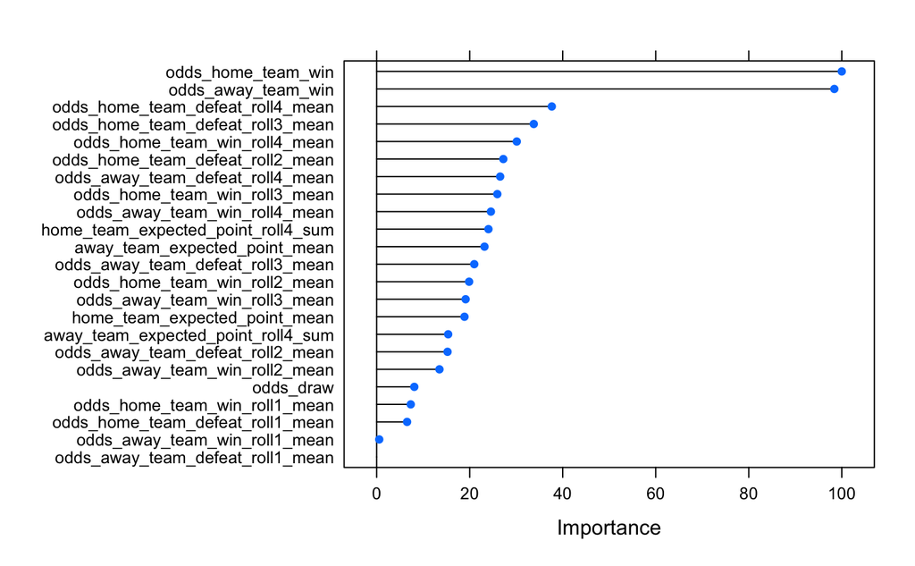

```r
varimp <- varImp(svm_model)
plot(varImp(svm_model))
```

## K-Nearest Neighbours

```r
#  train the model
set.seed(19900829)
tune_grid_knn <- expand.grid(
  .k= 5
)


knn_model <- train(
  home_win_flag ~ .,
  data = data_train[ ,colnames(data_train) %in% c("home_win_flag", predictors_1), with=FALSE],
  tuneLength = 1,
  method = 'knn',
  na.action = na.omit,
  # importance = 'permutation',
  # mtry: cannot be more than the number of predictors
  tuneGrid = tune_grid_knn,
  trControl = train_control)
```

```r
# model summary
summary(knn_model)
```

```
            Length Class      Mode
learn       2      -none-     list
k           1      -none-     numeric
theDots     0      -none-     list
xNames      3      -none-     character
problemType 1      -none-     character
tuneValue   1      data.frame list
obsLevels   2      -none-     character
param       0      -none-     list
```

```r
# AUC on validation set
auc_cv <- knn_model[["results"]][["ROC"]]
message(paste0("AUC from CV: ", round(auc_cv, digits = 4)))
```

```
AUC from CV: 0.6307
```

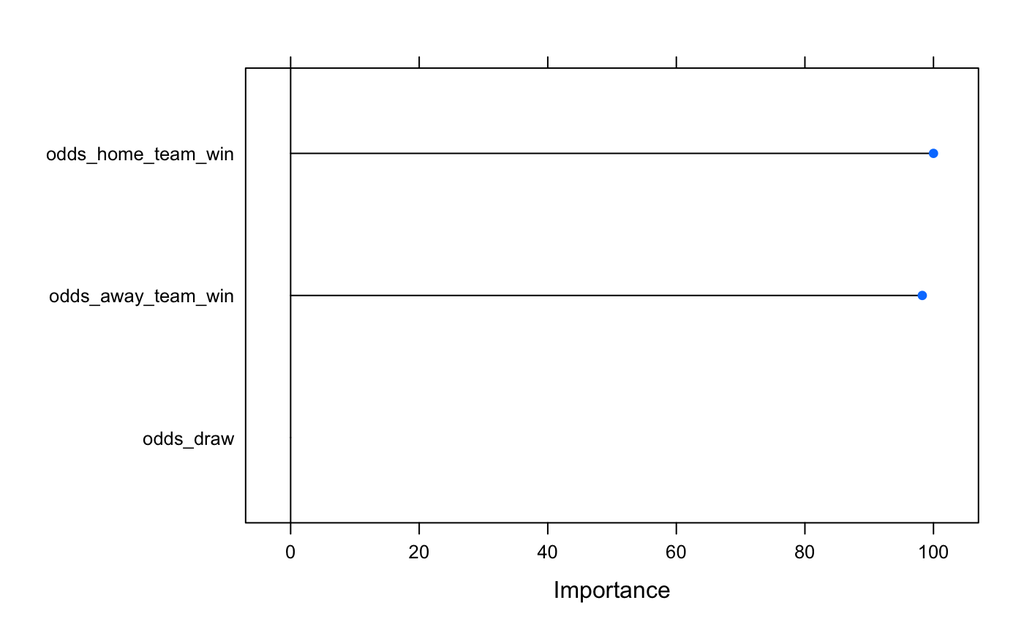

```r
varimp <- varImp(knn_model)
plot(varImp(knn_model))
```

## ENSEMBLED MODEL

```r
h2o.init()
```

```
H2O is not running yet, starting it now...

Note:  In case of errors look at the following log files:
    /var/folders/v_/l5zp744d5z350b__prjsk4r40000gn/T//Rtmpy2X3fV/file22a3b15219a/h2o_attilagulyas_started_from_r.out
    /var/folders/v_/l5zp744d5z350b__prjsk4r40000gn/T//Rtmpy2X3fV/file22a318510b25/h2o_attilagulyas_started_from_r.err
```

```
java version "1.8.0_361"
Java(TM) SE Runtime Environment (build 1.8.0_361-b09)
Java HotSpot(TM) 64-Bit Server VM (build 25.361-b09, mixed mode)
```

[output not shown]

```r
data_train_h2o <- as.h2o(data_train[,-c("away_win_flag", "draw_flag")])
# Identify predictors and response
y <- "home_win_flag"
x <- predictors_2

# Train & Cross-validate a GBM
my_gbm <- h2o.gbm(x = x,
                  y = y,
                  training_frame = data_train_h2o,
                  nfolds = 5,
                  keep_cross_validation_predictions = TRUE,
                  seed = 5)
# Train & Cross-validate a RF
my_rf <- h2o.randomForest(x = x,
                          y = y,
                          training_frame = data_train_h2o,
                          nfolds = 5,
                          keep_cross_validation_predictions = TRUE,
                          seed = 5)
# Train & Cross-validate a LR
my_lr <- h2o.glm(x = x,
                 y = y,
                 training_frame = data_train_h2o,
                 family = c("binomial"),
                 nfolds = 5,
                 keep_cross_validation_predictions = TRUE,
                 seed = 5)
# Train a stacked random forest ensemble using the GBM, RF and LR above
ensemble <- h2o.stackedEnsemble(x = x,
                                y = y,
                                metalearner_algorithm="drf",
                                training_frame = data_train_h2o,
                                base_models = list(my_gbm, my_rf, my_lr))
```

```r
# model summary
summary(ensemble)
```

[output not shown]

| EVALUATION: Compare random forests models based on VALIDATION sets |
| --- |

```r
results <- resamples(
  list(
    #model_1 = aml,
    GLM = glm_model,
    XGB = xgb_model,
    GMB = gbm_model,
    NB = nb_model,
    RF = rf_model,
    SVM = svm_model,
    KNN = knn_model
    #model_9 = ensemble
  )
)
summary(results)
```

```
Call:
summary.resamples(object = results)

Models: GLM, XGB, GMB, NB, RF, SVM, KNN
Number of resamples: 5

ROC
         Min.   1st Qu.    Median      Mean   3rd Qu.      Max. NA's
GLM 0.6786576 0.6804520 0.6813941 0.6813631 0.6827220 0.6835897    0
XGB 0.6578328 0.6629525 0.6642293 0.6632877 0.6646021 0.6668218    0
GMB 0.6770801 0.6803969 0.6815498 0.6810688 0.6820824 0.6842350    0
NB  0.6571091 0.6614135 0.6627554 0.6628852 0.6657889 0.6673592    0
RF  0.6687132 0.6692642 0.6722901 0.6715790 0.6730861 0.6745414    0
SVM 0.6731218 0.6764376 0.6774208 0.6768380 0.6781964 0.6790133    0
KNN 0.6249539 0.6287373 0.6289225 0.6306673 0.6353330 0.6353900    0

Sens
         Min.   1st Qu.    Median      Mean   3rd Qu.      Max. NA's
GLM 0.8130340 0.8166104 0.8166104 0.8164984 0.8180373 0.8181999    0
XGB 0.7444864 0.7478641 0.7502484 0.7518874 0.7526818 0.7641566    0
GMB 0.9310550 0.9429764 0.9487383 0.9465942 0.9543016 0.9558999    0
NB  0.8491953 0.8539638 0.8559507 0.8563137 0.8573415 0.8651172    0
RF  0.7985297 0.8021061 0.8044904 0.8038622 0.8060799 0.8081049    0
SVM 0.8791973 0.8811842 0.8823763 0.8826987 0.8827737 0.8879619    0
KNN 0.7061979 0.7103119 0.7103119 0.7111184 0.7130936 0.7156765    0

Spec
         Min.   1st Qu.    Median      Mean   3rd Qu.      Max. NA's
GLM 0.3969620 0.4062263 0.4177215 0.4125870 0.4194937 0.4225316    0
XGB 0.4551899 0.4577215 0.4622785 0.4654942 0.4635443 0.4887370    0
GMB 0.1734177 0.1800000 0.1908378 0.1899650 0.1962025 0.2093671    0
NB  0.3227848 0.3263291 0.3288608 0.3293502 0.3343457 0.3344304    0
RF  0.4075949 0.4083544 0.4118987 0.4136494 0.4151899 0.4252088    0
SVM 0.3002532 0.3040506 0.3108861 0.3110216 0.3159494 0.3239686    0
KNN 0.4689952 0.4693671 0.4746835 0.4741535 0.4787342 0.4789873    0
```

| EVALUATION: Compare random forests models based on TEST set |
| --- |

Logistic regression

```r
# AUC on holdout set
predicted_glm_holdout <- predict(glm_model,
                                 newdata = data_holdout,
                                 type = "prob")[["yes"]]


prediction_holdout_glm <- prediction(predicted_glm_holdout, data_holdout$home_win_flag)
auc_holdout_glm <- performance(prediction_holdout_glm, measure = "auc")@y.values[[1]]
message(paste0("AUC on holdout set for GLM: ", round(auc_holdout_glm, digits = 4)))
```

```
AUC on holdout set for GLM: 0.68
```

GLMNET

```r
# AUC on holdout set
predicted_glmnet_holdout <- predict(glmnet_model,
                                 newdata = data_holdout,
                                 type = "prob")[["yes"]]


prediction_holdout_glmnet <- prediction(predicted_glmnet_holdout, data_holdout$home_win_flag)
auc_holdout_glmnet <- performance(prediction_holdout_glmnet, measure = "auc")@y.values[[1]]
message(paste0("AUC on holdout set for GLM Net: ", round(auc_holdout_glmnet, digits = 4)))
```

```
AUC on holdout set for GLM Net: 0.68
```

Random forest

```r
# AUC on holdout set
predicted_rf_holdout <- predict(rf_model,
                         newdata = data_holdout,
                         type = "prob")[["yes"]]


prediction_holdout_rf <- prediction(predicted_rf_holdout, data_holdout$home_win_flag)
auc_holdout_rf <- performance(prediction_holdout_rf, measure = "auc")@y.values[[1]]
message(paste0("AUC on holdout set for RF: ", round(auc_holdout_rf, digits = 4)))
```

```
AUC on holdout set for RF: 0.6704
```

XGBoosting

```r
# AUC on holdout set
predicted_xgb_holdout <- predict(xgb_model,
                         newdata = data_holdout,
                         type = "prob")[["yes"]]


prediction_holdout_xgb <- prediction(predicted_xgb_holdout, data_holdout$home_win_flag)
auc_holdout_xgb <- performance(prediction_holdout_xgb, measure = "auc")@y.values[[1]]
message(paste0("AUC on holdout set for XGB: ", round(auc_holdout_xgb, digits = 4)))
```

```
AUC on holdout set for XGB: 0.6612
```

Gradient Boosting Machine

```r
# AUC on holdout set
predicted_gbm_holdout <- predict(gbm_model,
                         newdata = data_holdout,
                         type = "prob")[["yes"]]


prediction_holdout_gbm <- prediction(predicted_gbm_holdout, data_holdout$home_win_flag)
auc_holdout_gbm <- performance(prediction_holdout_gbm, measure = "auc")@y.values[[1]]
message(paste0("AUC on holdout set for GBM: ", round(auc_holdout_gbm, digits = 4)))
```

```
AUC on holdout set for GBM: 0.6799
```

Naive Bayes

```r
# AUC on holdout set
predicted_nb_holdout <- predict(nb_model,
                         newdata = data_holdout,
                         type = "prob")[["yes"]]


prediction_holdout_nb <- prediction(predicted_nb_holdout, data_holdout$home_win_flag)
auc_holdout_nb <- performance(prediction_holdout_nb, measure = "auc")@y.values[[1]]
message(paste0("AUC on holdout set for NB: ", round(auc_holdout_nb, digits = 4)))
```

```
AUC on holdout set for NB: 0.6626
```

SVM

```r
# AUC on holdout set
predicted_svm_holdout <- predict(svm_model,
                         newdata = data_holdout,
                         type = "prob")[["yes"]]


prediction_holdout_svm <- prediction(predicted_svm_holdout, data_holdout$home_win_flag)
auc_holdout_svm <- performance(prediction_holdout_svm, measure = "auc")@y.values[[1]]
message(paste0("AUC on holdout set for SVM: ", round(auc_holdout_svm, digits = 4)))
```

```
AUC on holdout set for SVM: 0.6761
```

KNN

```r
# AUC on holdout set
predicted_knn_holdout <- predict(knn_model,
                         newdata = data_holdout,
                         type = "prob")[["yes"]]


prediction_holdout_knn <- prediction(predicted_knn_holdout, data_holdout$home_win_flag)
auc_holdout_knn <- performance(prediction_holdout_knn, measure = "auc")@y.values[[1]]
message(paste0("AUC on holdout set for KNN: ", round(auc_holdout_knn, digits = 4)))
```

```
AUC on holdout set for KNN: 0.6393
```

## ODDS based probability

```r
data_holdout[,.prob_home_win_odds_based := 1/(1+odds_home_team_win)]
data_holdout[,.prob_draw_odds_based := 1/(1+odds_draw)]
data_holdout[,.prob_away_win_odds_based := 1/(1+odds_away_team_win)]

data_holdout[,.prob_sum_odds_based := .prob_home_win_odds_based + .prob_draw_odds_based + .prob_away_win_odds_based]

data_holdout[,.prob_home_win_odds_based_adj := .prob_home_win_odds_based / .prob_sum_odds_based]
data_holdout[,.prob_draw_odds_based_adj := .prob_draw_odds_based / .prob_sum_odds_based]
data_holdout[,.prob_away_win_odds_based_adj := .prob_away_win_odds_based / .prob_sum_odds_based]
```

COLLECT PREDICTIONS INTO A OUTPUT TABLE

```r
predcition_lists <-c("GLM" = prediction_holdout_glm@predictions,
                     "GBM" = prediction_holdout_gbm@predictions,
                     "XGB" = prediction_holdout_xgb@predictions,
                     "RF" = prediction_holdout_rf@predictions,
                     "NB" = prediction_holdout_nb@predictions,
                     "KNN" = prediction_holdout_knn@predictions,
                     "SVM" = prediction_holdout_svm@predictions)
prediction_table <-data.table(do.call(cbind, predcition_lists))

# model average
prediction_table$mean = (prediction_table$GLM + prediction_table$GBM + prediction_table$XGB + prediction_table$RF + prediction_table$NB + prediction_table$KNN + prediction_table$SVM ) / 7

# odds based
prediction_table$odds_based <- data_holdout$.prob_home_win_odds_based_adj

# Results - fact
prediction_table$actual <- data_holdout$home_win_flag
```

```r
# Calculate AUC manually

auc_holdout_mean <- auc_roc(preds = prediction_table$mean, actuals = ordered(prediction_table$actual))
auc_holdout_oddsbased<- auc_roc(preds = prediction_table$odds_based, actuals = ordered(prediction_table$actual))

message(paste0("AUC on holdout set for Mean Model: ", round(auc_holdout_mean, digits = 4)))
```

```
AUC on holdout set for Mean Model: 0.6753
```

```r
message(paste0("AUC on holdout set for ODDS based Model: ", round(auc_holdout_oddsbased, digits = 4)))
```

```
AUC on holdout set for ODDS based Model: 0.6802
```

ROC curve on the TEST set

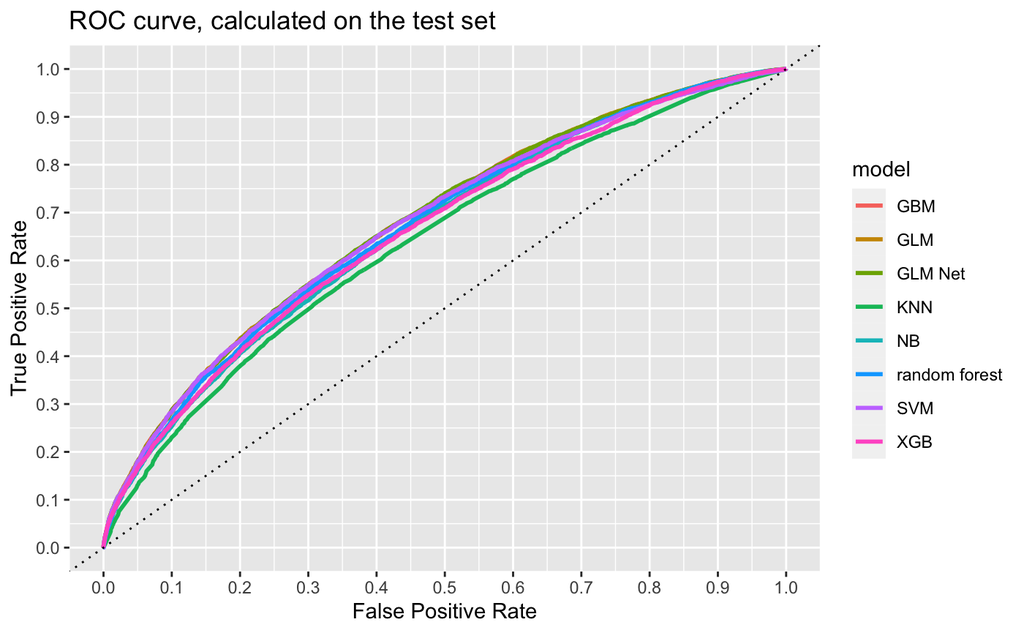

```r
roc_df_logit_rf <- imap(list("random forest" = rf_model,
                             "GLM Net" = glmnet_model,
                             "GLM" = glm_model,
                             "GBM" = gbm_model,
                             "XGB" = xgb_model,
                             "NB" = nb_model,
                             "KNN" = knn_model,
                             "SVM" = svm_model
                             ), ~ {
  model <- .x
  predicted_probabilities <- predict(model, newdata = data_holdout, type = "prob")
  rocr_prediction <- prediction(predicted_probabilities[["yes"]], data_holdout[["home_win_flag"]])

  tpr_fpr_performance <- performance(rocr_prediction, "tpr", "fpr")
  tibble(
    model = .y,
    FPR = tpr_fpr_performance@x.values[[1]],
    TPR = tpr_fpr_performance@y.values[[1]],
    cutoff = tpr_fpr_performance@alpha.values[[1]]
  )
}) %>% bind_rows()

ggplot(roc_df_logit_rf) +
  geom_line(aes(FPR, TPR, color = model), size = 1) +
  geom_abline(intercept = 0, slope = 1,  linetype = "dotted", col = "black") +
  scale_y_continuous(limits = c(0, 1), breaks = seq(0, 1, .1)) +
  scale_x_continuous(limits = c(0, 1), breaks = seq(0, 1, .1)) +
  xlab("False Positive Rate") + ylab("True Positive Rate") +
  ggtitle("ROC curve, calculated on the test set")
```

SAVE MODELS

```r
saveRDS(rf_model, paste0(output,"home_model_rf.rda"))
saveRDS(glm_model, paste0(output,"home_model_glm.rda"))
saveRDS(gbm_model, paste0(output,"home_model_gbm.rda"))
saveRDS(xgb_model, paste0(output,"home_model_xgb.rda"))
saveRDS(nb_model, paste0(output,"home_model_nb.rda"))
saveRDS(knn_model, paste0(output,"home_model_knn.rda"))
saveRDS(svm_model, paste0(output,"home_model_svm.rda"))
```

LOAD MODELS

```r
home_model_rf <- readRDS(paste0(output,"home_model_rf.rda"))
home_model_glm <- readRDS(paste0(output,"home_model_glm.rda"))
home_model_gbm <- readRDS(paste0(output,"home_model_gbm.rda"))
home_model_xgb <- readRDS(paste0(output,"home_model_xgb.rda"))
home_model_nb <- readRDS(paste0(output,"home_model_nb.rda"))
home_model_knn <- readRDS(paste0(output,"home_model_knn.rda"))
home_model_svm <- readRDS(paste0(output,"home_model_svm.rda"))
```

TRY LOADED MODEL

```r
# AUC on holdout set
predicted_proba_holdout <- predict(home_model_rf,
                         newdata = data_holdout,
                         type = "prob")[["yes"]]


prediction_holdout_proba <- prediction(predicted_proba_holdout, data_holdout$home_win_flag)
auc_holdout_proba <- performance(prediction_holdout_proba, measure = "auc")@y.values[[1]]
message(paste0("AUC on holdout set for RF: ", round(auc_holdout_proba, digits = 4)))
```

```
AUC on holdout set for RF: 0.6704
```

CALIBRATION TEST

```r
# calibration plot: how well do estimated vs actual event probabilities relate to each other?
# -------------------------------------------------
actual_vs_predicted_rf1 <- data.frame(
  actual = ifelse(data_holdout[["home_win_flag"]] == "yes", 1, 0),
  predicted = predicted_rf1_holdout
)

# order observations accordingly

num_groups <- 10

calibration_logit <- actual_vs_predicted_rf1 %>%
  # ntile: assign group ids based on a variable. similar to "cut".
  mutate(predicted_score_group = ntile(predicted, num_groups)) %>%
  group_by(predicted_score_group) %>%
  summarise(mean_actual = mean(actual), mean_predicted = mean(predicted), num_obs = n())

ggplot(calibration_logit,aes(x = mean_actual, y = mean_predicted)) +
  geom_point() +
  geom_abline(intercept = 0, slope = 1, linetype = "dashed") +
  labs(x = "Actual event probability", y = "Predicted event probability") +
  ylim(0, 1) + xlim(0, 1)


# the Brier score: MSE applied to classification evaluation

brier <- RMSE(actual_vs_predicted_rf1[["predicted"]], actual_vs_predicted_rf1[["actual"]])^2
message(paste0("Brier score: ", round(brier, digits = 4)))
```

[output not shown]